# Lab 10 - Stats 503

## USA Presidential Election Results (2016)

The dataset comes from Kaggle (https://www.kaggle.com/joelwilson/2012-2016-presidential-elections). Our goal today is to predict the winner candidate on each county based on demographic data.

Note: this analysis was part of a final project in Stats 503 - 2016 (but using the primary election results).

```r
votes = read.csv("Data/votes.csv", header = T)
candidate = ifelse(votes$Trump > votes$Clinton, "Trump", "Clinton")
table(candidate) / length(candidate)
```

```
## candidate
##   Clinton     Trump
## 0.1568123 0.8431877
```

Some variables are selected (see Data/county_facts_dictionary).

```r
county_demo = data.frame(State = votes$state_abbr,
                          Age_5 = votes$AGE135214,
                          Age_6_18 = 100 - votes$AGE295214,
                          Age_19_64 = 100 - votes$AGE135214 - votes$AGE295214 - votes$AGE295214,
                          Age_65 = votes$AGE295214,
                          Females = votes$SEX255214,
                          White = votes$White,
                          Black = votes$Black,
                          Native = votes$RHI325214,
                          Asian = votes$RHI425214,
                          Hawaian = votes$RHI525214,
                          Hispanic = votes$Hispanic,
                          Foreignborn = votes$POP645213,
                          OtherLanguageatHome = votes$NonEnglish,
                          NoHighSchool = 100 - votes$Edu_highschool - votes$Edu_batchelors,
                          HighSchool = votes$Edu_highschool,
                          Bachelorplus = votes$Edu_batchelors,
                          PopulationDensity = votes$population2014 / votes$LND110210)
df = data.frame(candidate = factor(candidate), county_demo)
```

## Classification trees

```r
library(rpart)
election_tr = rpart(candidate~., data=df)
election_tr
```

```
## n= 3112
##
## node), split, n, loss, yval, (yprob)
##       * denotes terminal node
##
##   1) root 3112 488 Trump (0.15681234 0.84318766)
##     2) White< 0.5365 187  35 Clinton (0.81283422 0.18716578)
##       4) Black>=0.5095 93   1 Clinton (0.98924731 0.01075269) *
##       5) Black< 0.5095 94  34 Clinton (0.63829787 0.36170213)
##        10) Asian>=1.05 35   1 Clinton (0.97142857 0.02857143) *
##        11) Asian< 1.05 59  26 Trump (0.44067797 0.55932203)
##          22) Females>=49.9 40  16 Clinton (0.60000000 0.40000000)
##            44) State=AR,AZ,MT,NC,ND,NM,SC,SD,TN,VA 24   4 Clinton (0.83333333 0.16666667) *
##            45) State=AL,GA,LA,MS,NE,OK,UT 16   4 Trump (0.25000000 0.75000000) *
##          23) Females< 49.9 19   2 Trump (0.10526316 0.89473684) *
##     3) White>=0.5365 2925 336 Trump (0.11487179 0.88512821)
##       6) Bachelorplus>=27.95 454 224 Clinton (0.50660793 0.49339207)
##        12) State=AZ,CA,CO,CT,DE,FL,IA,IL,MA,ME,MN,NC,NH,NJ,NM,NY,OH,OR,PA,RI,VA,VT,WA,WI,WY 290  97 Clinton (0.66551724 0.33448276)
##          24) Asian>=4.15 107  12 Clinton (0.88785047 0.11214953) *
##          25) Asian< 4.15 183  85 Clinton (0.53551913 0.46448087)
##            50) State=CA,MA,ME,NM,RI,VT 37   2 Clinton (0.94594595 0.05405405) *
##            51) State=AZ,CO,CT,FL,IA,IL,MN,NC,NH,NJ,NY,OH,OR,PA,VA,WA,WI,WY 146  63 Trump (0.43150685 0.56849315)
##             102) PopulationDensity>=835.7376 25   6 Clinton (0.76000000 0.24000000) *
##             103) PopulationDensity< 835.7376 121  44 Trump (0.36363636 0.63636364)
##               206) State=AZ,CO,CT,IA,IL,NC,NH,WA,WY 63  30 Clinton (0.52380952 0.47619048)
##                 412) Bachelorplus>=35.8 24   5 Clinton (0.79166667 0.20833333) *
##                 413) Bachelorplus< 35.8 39  14 Trump (0.35897436 0.64102564) *
##               207) State=FL,MN,NJ,NY,OH,OR,PA,VA,WI 58  11 Trump (0.18965517 0.81034483) *
##        13) State=AL,AR,GA,ID,IN,KS,KY,LA,MD,MI,MO,MS,MT,ND,NE,OK,SC,SD,TN,TX,UT,WV 164  37 Trump (0.22560976 0.77439024)
##          26) PopulationDensity>=1223.308 15   1 Clinton (0.93333333 0.06666667) *
##          27) PopulationDensity< 1223.308 149  23 Trump (0.15436242 0.84563758) *
##       7) Bachelorplus< 27.95 2471 106 Trump (0.04289761 0.95710239)
##        14) Hispanic>=0.711 29   1 Clinton (0.96551724 0.03448276) *
##        15) Hispanic< 0.711 2442  78 Trump (0.03194103 0.96805897) *
```

### Plotting trees

Basic plot

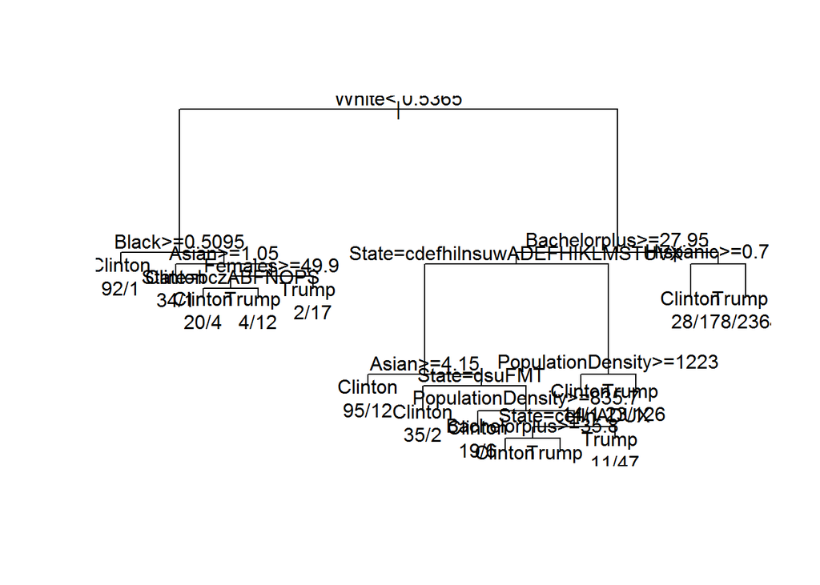

```r
plot(election_tr, compress = TRUE)
text(election_tr, use.n = TRUE)
```

Some nicer options.

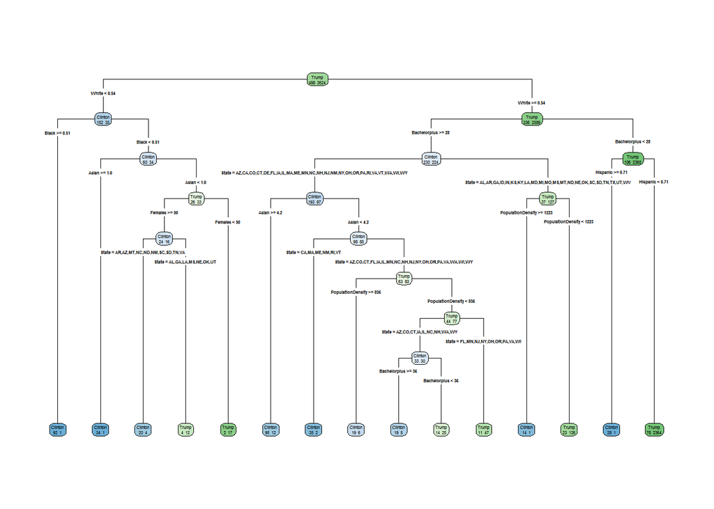

```r
library(rpart.plot)
rpart.plot(election_tr, type = 4,extra = 1,clip.right.labs = F)
```

```r
library(rattle)
```

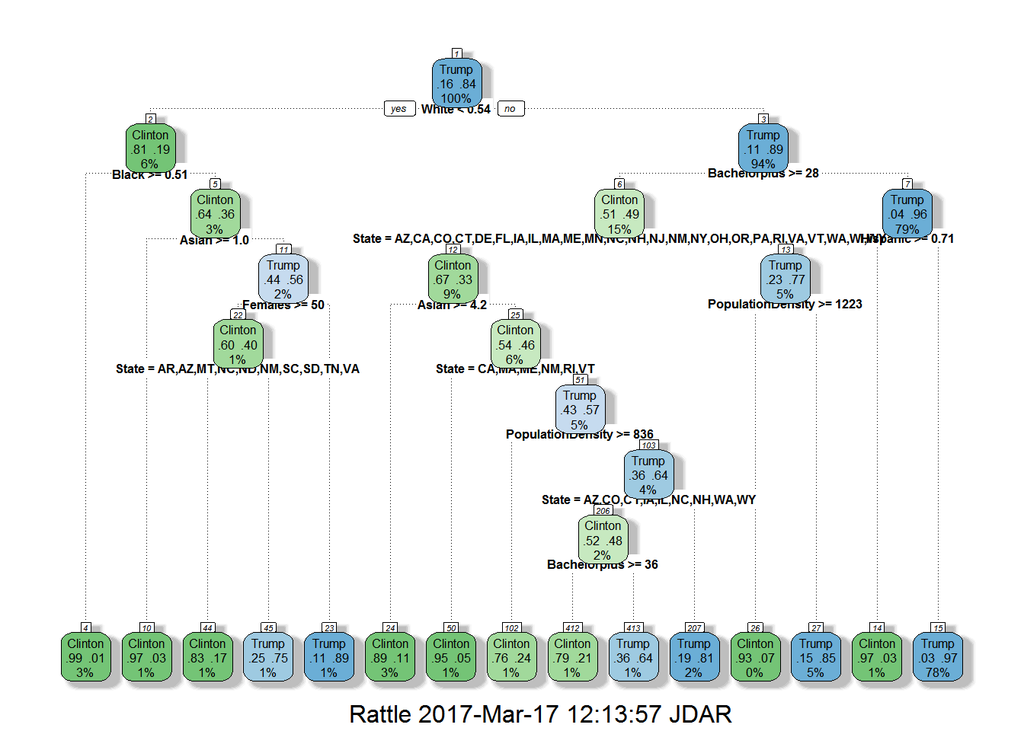

```r
fancyRpartPlot(election_tr, cex = 0.5)
```

### Tuning parameters

Cp controls the complexity of the tree (minsplit and minbucket too). Split controls the impurity measure.

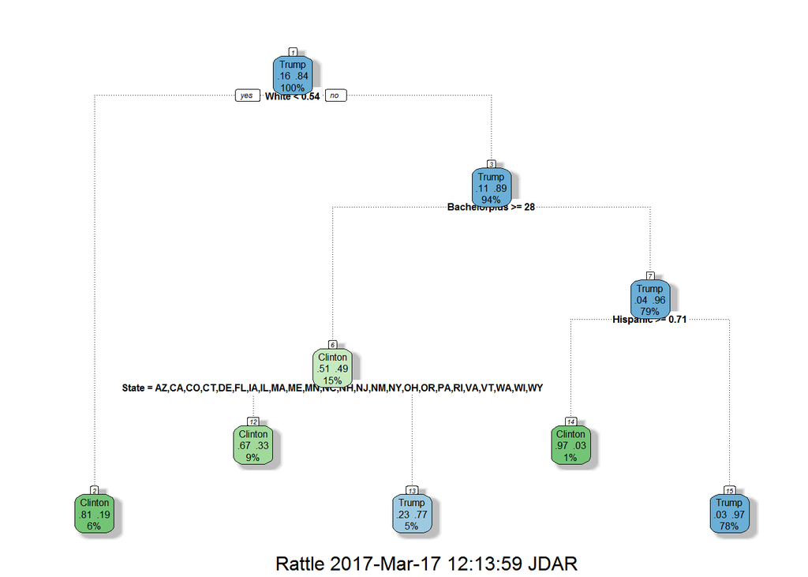

```r
control = rpart.control(cp = 0.05, minsplit = 2)
election_tr = rpart(candidate~., data=df,
                  parms = list(split = "gini"), control = control)
fancyRpartPlot(election_tr, cex = 0.5)
```

Cp can be chosen using cross-validation

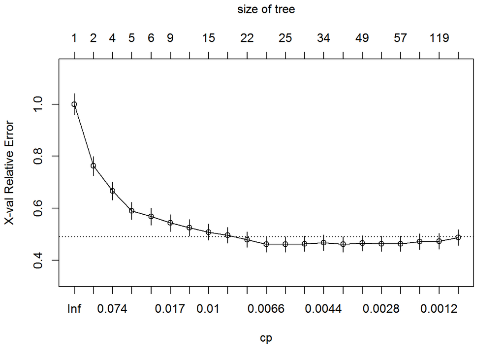

```r
control = rpart.control(cp = 0.000, xxval = 100, minsplit = 2)
election_tr = rpart(candidate ~ ., data = df, control = control)
plotcp(election_tr)
```

```r
printcp(election_tr)
```

```
##
## Classification tree:
## rpart(formula = candidate ~ ., data = df, control = control)
##
## Variables actually used in tree construction:
##  [1] Age_19_64           Age_5               Age_6_18
##  [4] Asian               Bachelorplus        Black
##  [7] Females             Foreignborn         Hawaian
## [10] HighSchool          Hispanic            Native
## [13] NoHighSchool        OtherLanguageatHome PopulationDensity
## [16] State               White
##
## Root node error: 488/3112 = 0.15681
##
## n= 3112
```

[output cut: 23 more lines]

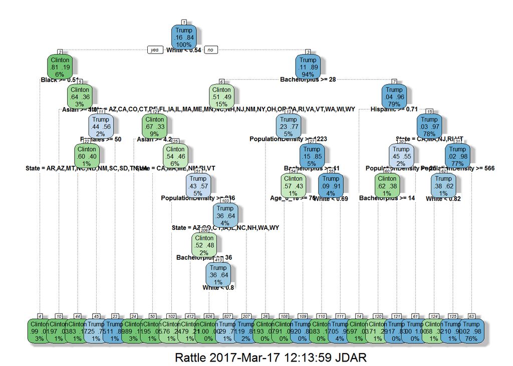

```r
selected_tr <- prune(election_tr, cp=   election_tr$cptable[which.min(election_tr$cptable[,"xerror"]),"CP"])
fancyRpartPlot(selected_tr, cex = 0.5)
```

### Boundary plot

https://jesusdaniel.shinyapps.io/Lab10-shinytree/

## Random forest

```r
library(randomForest)
election_rf = randomForest(candidate~., mtry= 2, ntree= 1000, data=df)
election_rf
```

```
##
## Call:
##  randomForest(formula = candidate ~ ., data = df, mtry = 2, ntree = 1000)
##                Type of random forest: classification
##                      Number of trees: 1000
## No. of variables tried at each split: 2
##
##         OOB estimate of  error rate: 8.52%
## Confusion matrix:
##         Clinton Trump class.error
## Clinton     424    64  0.13114754
## Trump       201  2423  0.07660061
```

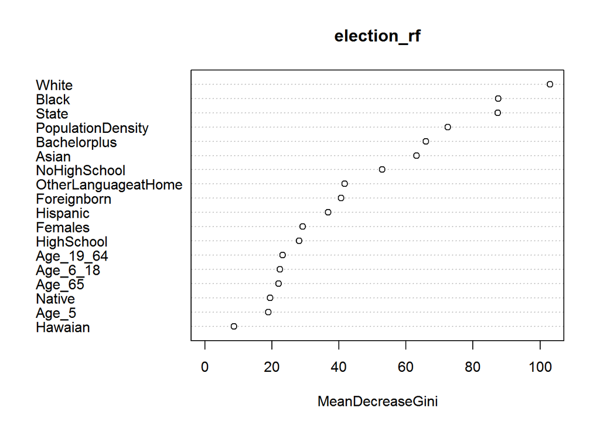

```r
varImpPlot(election_rf)
```

```r
control = rpart.control(cp = 0.001, minsplit = 2)
election_rf = randomForest(candidate~., mtry= 2, ntree= 1000, data=df, control = control)
election_rf
```

```
##
## Call:
##  randomForest(formula = candidate ~ ., data = df, mtry = 2, ntree = 1000,      control = control)
##                Type of random forest: classification
##                      Number of trees: 1000
## No. of variables tried at each split: 2
##
##         OOB estimate of  error rate: 9.09%
## Confusion matrix:
##         Clinton Trump class.error
## Clinton     425    63  0.12909836
## Trump       220  2404  0.08384146
```

```r
tuneelection_rf = tuneRF(x = df[,-1], y = df$candidate)
```

```
## mtry = 4  OOB error = 29.05%
## Searching left ...
## mtry = 2     OOB error = 15.75%
## 0.4579646 0.05
## mtry = 1     OOB error = 8.71%
## 0.4469388 0.05
## Searching right ...
## mtry = 8     OOB error = 51.74%
## -4.940959 0.05
```

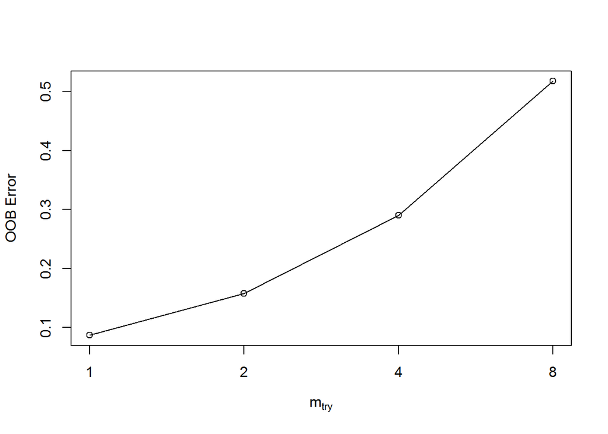

```r
tuneelection_rf
```

```
##       mtry   OOBError
## 1.OOB    1 0.08708226
## 2.OOB    2 0.15745501
## 4.OOB    4 0.29048843
## 8.OOB    8 0.51735219
```

### Boundary plot

https://jesusdaniel.shinyapps.io/Lab10-shinyRF/

Miscellaneous: Neural networks boundaries https://jesusdaniel.shinyapps.io/Lab10-shinynnet/

## Exercises - Boosting

1. Use boosting to predict the candidate winner on each county. You can use the package *ada* (which only works for binary problems), or *adabag* (also works for multiclass problems).
2. Compute the out-of-bag error and the variable importance plot of your classifier.
3. Play with the parameters and find the best classifier. You are also allowed to play with the variables (include other variables from the original dataset, or use transformations on some of them).